# R ekosisteminde metin madenciliği nasıl yapılır?

Veri gazeteciliği süreçlerinde sayılar kadar metinler de niceliksel analizin bir parçası olarak kullanılıyor.Çünkü metin de ürettiğimiz, kullandığımız ve paylaştığımız bir veri. Özellikle siyasilerin konuşmaları, bir twitter etiketi içinde paylaşılan tweetler veyahut devletin bir kurumu tarafından yayınlanan bir rapor gazeteciler tarafından metin madenciliği sayesinde habercilik amaçları için kullanılabiliyor. Bu saydıklarıma örnek olarak Trump’ın sinirli tweetlerini Android cihazından paylaştığını, Cumhuriyetçilerin ve Demokratları söylemleri gösterebiliriz.

Metin madenciliğini veri madenciliğinin bir alt başlığı olarak tanımlamak yanlış olmaz. Yapılan işlem normalde analiz edilemeyen yapılandırılmamış büyük metin bloglarınının belirli komputasyonel yöntemlerle analiz edilmesi, anlamlandırılması ve metin verisinden belirli temalar, trendler, ilişkiler elde edilmesidir.

Metin madenciliği geniş bir alan. Python ve R gibi araçlarla gelişmiş analizler ve çalışmalar yapılabiliyor. Daha çok metin madenciliğine giriş niteliğine sahip olacak bu yazıda R ekosisteminde metin verileri nasıl analiz edilebileceğini ve görselleştirileceğini anlatacağım.

#### Hazırlık

```r
#paketleri aktif hale getirmeden önce lütfen yükleyin (install.packages("paket ismi"))

library("tidytext") #metin verilerini bu paketle analiz edeceğiz
library("tidyverse") #dplyr, ggplot2, tidyr gibi paketleri barındırıyor
library("rtweet") #tweetleri çekmek için kullanacağız.
library("rvest")
library("wordcloud2") #kelime bulutu görseli için
library("stopwords")
```

#### **Düz Metin Verisisini R’a aktaralım**

```r
nh <- read_lines("C:/Users/Sadettin/Desktop/nh.txt")
head(nh)
```

```
[1] "Haydarpaşa garında"
[2] "1941 baharında"
[3] "        saat on beş."
[4] "Merdivenlerin üstünde güneş"
[5] "                                            yorgunluk"
[6] "                                                        ve telaş."
```

```r
tail(nh)
```

```
[1] "Ali kımıldamadı."                       "Ali cevap vermedi Recep’e."
[3] "Tuttu delikanlıyı Recep"                "                    çevirdi arka üstü."
[5] "Ali’nin başı düştü."                    "Ali çoktan ölmüştü."
```

```r
nh_tidy <- paste0(nh, collapse = " ")

nh_tablo <- tibble(nh_tidy)

str(nh_tablo)
```

```
Classes ‘tbl_df’, ‘tbl’ and 'data.frame':   1 obs. of  1 variable:
 $ nh_tidy: chr "Haydarpaşa garında 1941 baharında         saat on beş. Merdivenlerin üstünde güneş                             "| __truncated__
```

Nazım Hikmet’in Şiiri aşağıda analiz edilecektir.

#### **1. Trump’ın Tweetleri**

```r
trumptweets<-readRDS("C:/Users/Sadettin/Rstats/metin-maden/trumptweets.rds")
```

Sadece tweet metinlerini filtreleyerek bir kenara alalım

```r
trump <- trumptweets %>% select(5)

head(trump)
```

| text |
| --- |
| ....This makes Nervous Nancy every bit as guilty as Liddle’ Adam Schiff for High Crimes and Misdemeanors, and even Treason. I guess that means that they, along with all of those that evilly “Colluded”… |
| Nancy Pelosi knew of all of the many Shifty Adam Schiff lies and massive frauds perpetrated upon Congress and the American people, in the form of a fraudulent speech knowingly delivered as a ruthless … |
| .@60Minutes “forgot” to report that we are helping the great farmers of the USA to the tune of 28 Billion Dollars, for the last two years, paid for out of Tariffs paid to the United States by China fo… |
| Unemployment Rate just dropped to 3.5%, the lowest in more that 50 years. Is that an impeachable event for your President? |
| Gerry Baker of @WSJatLarge “Do you think what you’ve seen rises to the level of impeachment?” Ken Starr, Clinton Special Prosecutor. “I don’t!” |
| Sleepy Eyes Chuck Todd of “Meet the Press” had a total meltdown in his interview with highly reaspected Senator @RonJohnsonWI. Seems that a not very bright Chuck just wasn’t getting the answers he was… |

```r
trumptidy <- trump %>%
  filter(!str_detect(text, '^"')) %>%
  mutate(text = str_replace_all(text, "https://t.co/[A-Za-z\\d]+|&amp;", ""))%>%
  unnest_tokens(word, text) %>%
  filter(!word %in% stop_words$word,
         str_detect(word, "[a-z]"))
```

```r
head(trumptidy)
```

| word |
| --- |
| makes |
| nervous |
| nancy |
| bit |
| guilty |
| liddle |

Sıklıkla kullanılan kelimlere göz atalım

```r
trumptidy %>% count(word, sort = TRUE)
```

| word | n |
| --- | --- |
| president | 456 |
| trump | 282 |
| people | 278 |
| democrats | 272 |
| news | 229 |
| country | 212 |
| realdonaldtrump | 197 |
| fake | 185 |
| media | 171 |
| america | 170 |

[output cut: 990 more lines]

Tekrar oranına göz atalım

```r
tekrar_oran <- trumptidy %>% count(word, sort = TRUE) %>%  mutate(tekrar = n/sum(n)*100)
```

```r
tekrar_oran
```

| word | n | tekrar |
| --- | --- | --- |
| president | 456 | 1.27076134 |
| trump | 282 | 0.78586557 |
| people | 278 | 0.77471854 |
| democrats | 272 | 0.75799799 |
| news | 229 | 0.63816743 |
| country | 212 | 0.59079255 |
| realdonaldtrump | 197 | 0.54899119 |
| fake | 185 | 0.51555011 |
| media | 171 | 0.47653550 |
| america | 170 | 0.47374875 |

[output cut: 990 more lines]

#### **N-gram ile sık kullanılan söz öbeklerini inceleyelim**

Bir diğer analiz ise arka arkaya gelen birden fazla ifadenin ne sıklıkla kullanıldığını bulabiliriz. Buna metin madenciliğinde *n-gram* yöntemi adı veriliyor.

Bu kısımda en önemli nokta unnest_tokens komutu içinde **tokeni** ngrams olarak değiştiriyoruz ve **n**’i 2’ye sabitliyoruz çünkü birbirini takip eden iki ayrı ifadeden oluşan söz öbeklerini elde etmek istiyoruz. Eğer dilersek bu değeri **3**’e çıkarıp daha fazla öbekten oluşan ifadelere de ulaşabiliriz. Bu analiz yöntemi tweetlerde, siyasilerin konuşmalarında, basın açıklamalarında, kitaplarda vb. metinlerde tekrar eden metinsel bir örüntü yakalamamızı sağlıyor.

```r
trump_bigrams <- trump %>%
  filter(!str_detect(text, '^"')) %>%
  mutate(text = str_replace_all(text, "https://t.co/[A-Za-z\\d]+|&amp;", "")) %>%
  unnest_tokens(bigram, text, token = "ngrams", n = 2)
```

```r
head(trump_bigrams)
```

| bigram |
| --- |
| this makes |
| makes nervous |
| nervous nancy |
| nancy every |
| every bit |
| bit as |

Hemen count() komutu ile sıklıkla kullanılan ifadelere göz atalım

```r
trump_bigrams %>% count(bigram, sort = TRUE)
```

| bigram | n |
| --- | --- |
| of the | 408 |
| in the | 310 |
| thank you | 220 |
| to the | 217 |
| at the | 191 |
| for the | 183 |
| will be | 173 |
| and the | 160 |
| on the | 155 |
| fake news | 142 |

[output cut: 990 more lines]

Görüldüğü üzere iki ayrı kelimenin birlikte kullanılma sayısı tek bir kelimeye göre daha az. Şimdi bu ifadelerdeki gereksiz kelimeleri (stopwords) veri setinden def edelim. Bunun için öncekinden daha karmaşık bir yöntem kullancacağız. Öncekine nazaran iki ifadeden oluşan ilk sütunu her biri bir kelimeden oluşacak şekilde ikiye ayırıp her sütunu ayrı ayrı temizleyeceğiz. Veri temizleme işlemi sonrası sütunları birleştirip gereksiz ifadelerden arınmış bigram sutunun tekrar hesaplayacağız.

O halde öncelikle bigram sütununu ikiye ayıralım

```r
trump_bigrams_tidy <-  trump_bigrams %>%
  separate(bigram, c("word1", "word2"), sep = " ") %>% #**ayırma**
  filter(!word1 %in% stop_words$word) %>% #temizleme aşaması 1
  filter(!word2 %in% stop_words$word) %>% #temizleme aşaması 2
  unite(bigram, word1, word2, sep = " ")%>% #birleştirme
  count(bigram, sort = TRUE)
```

```r
trump_bigrams_tidy
```

| bigram | n |
| --- | --- |
| fake news | 142 |
| president trump | 81 |
| witch hunt | 78 |
| president realdonaldtrump | 68 |
| north carolina | 63 |
| news media | 51 |
| prime minister | 39 |
| southern border | 39 |
| white house | 39 |
| hurricane dorian | 38 |

[output cut: 990 more lines]

**Nazım Hikmet’in Şiirini İnceleyelim**

```r
nh_veri <- nh_tablo %>%
  filter(!str_detect(nh_tidy, '^"')) %>%
  unnest_tokens(word, nh_tidy) %>%
  filter(!word %in% stopwords(language = "tr",source ="stopwords-iso"))

nh_veri
```

| word |
| --- |
| haydarpaşa |
| garında |
| 1941 |
| baharında |
| saat |
| merdivenlerin |
| üstünde |
| güneş |
| yorgunluk |
| telaş |

[output cut: 990 more lines]

```r
nh_veri %>% count(word, sort = TRUE)
```

| word | n |
| --- | --- |
| düşündü | 13 |
| yaşında | 13 |
| usta | 10 |
| merdivenleri | 9 |
| adam | 8 |
| ali | 8 |
| galip | 8 |
| kadın | 7 |
| recep | 7 |
| üstünde | 6 |

[output cut: 881 more lines]

#### **Metin Verilerinin Görselleştirilmesi**

Elimizdeki metin verilerileri en basit haliyle çubuk grafik veyahut kelime bulutu olarak görselleştirebiliriz.

```r
trump_bigrams_yeni<- trump_bigrams_tidy %>%
  filter(!bigram %in% str_detect("president")) %>%
  top_n(20,n)
```

[output not shown]

Görselleştirme

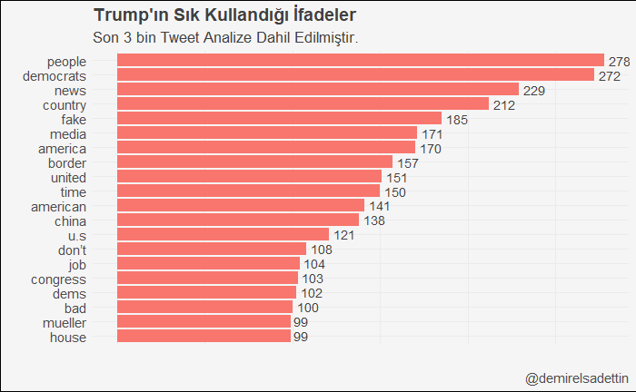

```r
renk <- c("söz_öbek"="",
          "kelime"="")


trump_tidy_yeni %>% ggplot(aes(fct_reorder(word, n),n, fill ="red"))+
  geom_col()+
  coord_flip()+
  geom_text(aes(x = word, y = n,label = n),check_overlap = TRUE, hjust = -0.2,size = 3.7,color= "gray25")+
  labs(x="",y="",
       title = "Trump'ın Sık Kullandığı İfadeler",
       subtitle = "Son 3 bin Tweet Analize Dahil Edilmiştir.",
       caption = "@demirelsadettin")+theme_custom2()
```

Söz Öbeklerş

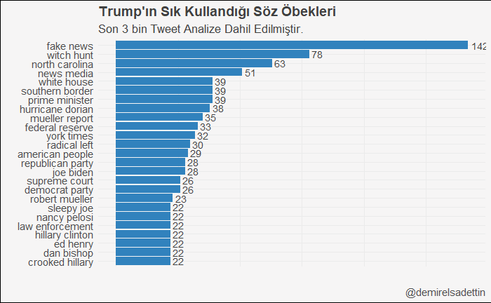

```r
values ="#3182bd"

trump_bigrams_yeni %>% ggplot(aes(fct_reorder(bigram, n),n, fill =values))+
  geom_col()+
  coord_flip()+ scale_fill_manual(values = "#3182bd")+
  geom_text(aes(x = bigram, y = n,label = n),check_overlap = TRUE, hjust = -0.2,size = 3.8,color= "gray25")+
  labs(x="",y="",
       title = "Trump'ın Sık Kullandığı Söz Öbekleri",
       subtitle = "Son 3 bin Tweet Analize Dahil Edilmiştir.",
       caption = "@demirelsadettin")+theme_custom2()
```

**Wordcloud2 paketi ile gelişmiş kelime bulutu**

[output not shown]

[output cut: 990 more lines]

```r
wordcloud2(data = trump_tidy_count,color = "random-light", backgroundColor = "grey25",size =0.6)
```

[output not shown]

Daha hoş bir kelime bulutu oluşturalım

```r
wordcloud2(data = trump_tidy_count,minRotation = -pi/6, maxRotation = -pi/6,
  rotateRatio = 1, size = 0.7)
```

[output not shown]

```r
trump_wordcloud <- trump_bigrams_tidy %>% filter(!bigram %in% c("president realdonaldtrump","president trump"))

wordcloud2(data = trump_wordcloud,minRotation = -pi/6, maxRotation = -pi/6,
  rotateRatio = 1, size = 0.7)
```

[output not shown]